# Baseball Data Analysis

Asaf Drizlikh, Xin Su, Steve Broll

December 14, 2017

## Introduction

```r
dta = read.csv('https://raw.githubusercontent.com/asafgibor/404finalproject/master/FinalReport/hof_all.csv')
```

```r
summary(dta)
```

```
##        X                 ID                    Name      HOF
##  Min.   :    2   aaronha01:   1   Alomar, Sandy  :   2   N:967
##  1st Qu.: 3192   adairje01:   1   Cruz, Jose     :   2   Y: 49
##  Median : 6134   adcocjo01:   1   Roberts, Dave  :   2
##  Mean   : 6213   ageeto01 :   1   Schofield, Dick:   2
##  3rd Qu.: 9288   aguaylu01:   1   Aaron, Hank    :   1
##  Max.   :12440   aldremi01:   1   Adair, Jerry   :   1
##                  (Other)  :1010   (Other)        :1006
##      HOF_n         HOF_mgr        FY             LY             SP
##  Min.   : 0.0000   N:1014   Min.   :1940   Min.   :1961   Min.   :10.00
##  1st Qu.: 0.0000   Y:   2   1st Qu.:1964   1st Qu.:1977   1st Qu.:11.00
##  Median : 0.0000            Median :1974   Median :1988   Median :13.00
##  Mean   : 0.9114            Mean   :1974   Mean   :1987   Mean   :13.54
##  3rd Qu.: 1.0000            3rd Qu.:1986   3rd Qu.:1999   3rd Qu.:15.00
##  Max.   :16.0000            Max.   :1999   Max.   :2008   Max.   :25.00
##
##       n_33            POS         ASG           G                AB
##  Min.   :10.00   Min.   :0.0000   N:757   Min.   : 140.0   Min.   :  252
##  1st Qu.:11.00   1st Qu.:0.0000   Y:259   1st Qu.: 937.5   1st Qu.: 2624
##  Median :13.00   Median :0.0000           Median :1287.5   Median : 4060
##  Mean   :13.54   Mean   :0.4163           Mean   :1344.2   Mean   : 4359
##  3rd Qu.:15.00   3rd Qu.:1.0000           3rd Qu.:1688.2   3rd Qu.: 5661
##  Max.   :25.00   Max.   :1.0000           Max.   :3308.0   Max.   :12364
##
##        R                H                DB              TP
##  Min.   :  2.00   Min.   :  4.80   Min.   :  6.0   Min.   :  0.00
##  1st Qu.: 30.57   1st Qu.: 65.67   1st Qu.:109.0   1st Qu.: 12.00
##  Median : 51.65   Median :106.25   Median :180.0   Median : 25.00
##  Mean   : 57.90   Mean   :116.67   Mean   :200.7   Mean   : 30.81
##  3rd Qu.: 76.55   3rd Qu.:154.38   3rd Qu.:267.0   3rd Qu.: 42.00
##  Max.   :229.50   Max.   :377.10   Max.   :725.0   Max.   :177.00
##
##        HR             RBI               SB               CS
##  Min.   :  0.0   Min.   :  2.10   Min.   :   0.0   Min.   :  0.00
##  1st Qu.: 36.0   1st Qu.: 27.38   1st Qu.:  15.0   1st Qu.: 15.00
##  Median : 84.0   Median : 45.40   Median :  41.0   Median : 31.00
##  Mean   :116.4   Mean   : 54.60   Mean   :  84.6   Mean   : 42.02
##  3rd Qu.:160.0   3rd Qu.: 72.03   3rd Qu.: 103.2   3rd Qu.: 58.00
##  Max.   :755.0   Max.   :229.70   Max.   :1406.0   Max.   :335.00
##
```

[output cut: 17 more lines]

```
##  Min.   :  1.90   Min.   :161.0   Min.   :222.0   Min.   :203.0
##  1st Qu.: 25.60   1st Qu.:249.0   1st Qu.:351.0   1st Qu.:310.0
##  Median : 43.90   Median :261.0   Median :393.0   Median :328.0
##  Mean   : 52.27   Mean   :261.4   Mean   :393.3   Mean   :328.3
##  3rd Qu.: 69.03   3rd Qu.:274.0   3rd Qu.:431.2   3rd Qu.:347.0
##  Max.   :359.60   Max.   :338.0   Max.   :565.0   Max.   :421.0
##
##       AW_P            AW_C              AWD             WAR
##  Min.   : 0.00   Min.   :0.00000   Min.   :0.000   Min.   :-0.9755
##  1st Qu.: 0.00   1st Qu.:0.00000   1st Qu.:0.000   1st Qu.: 0.6171
##  Median : 0.00   Median :0.00000   Median :0.000   Median : 1.4069
##  Mean   : 1.14   Mean   :0.08071   Mean   :0.315   Mean   : 1.5994
##  3rd Qu.: 1.00   3rd Qu.:0.00000   3rd Qu.:1.000   3rd Qu.: 2.4016
##  Max.   :20.00   Max.   :3.00000   Max.   :1.000   Max.   : 7.5602
##                                                    NA's   :1
```

## Data Preparation

```r
dta_num <- dta[,c(5,9:11,13:38)]
dta_num <- na.omit(dta_num) # listwise deletion of missing
dta <- na.omit(dta)
dim(dta_num)
```

```
## [1] 1015   30
```

## K-means

K-means clustering is the most popular partitioning method. It requires you to specify the number of clusters to extract. A plot of the within groups sum of squares by number of clusters extracted can help determine the appropriate number of clusters. An important feature in the plot is the bend, similar to a scree test in factor analysis.

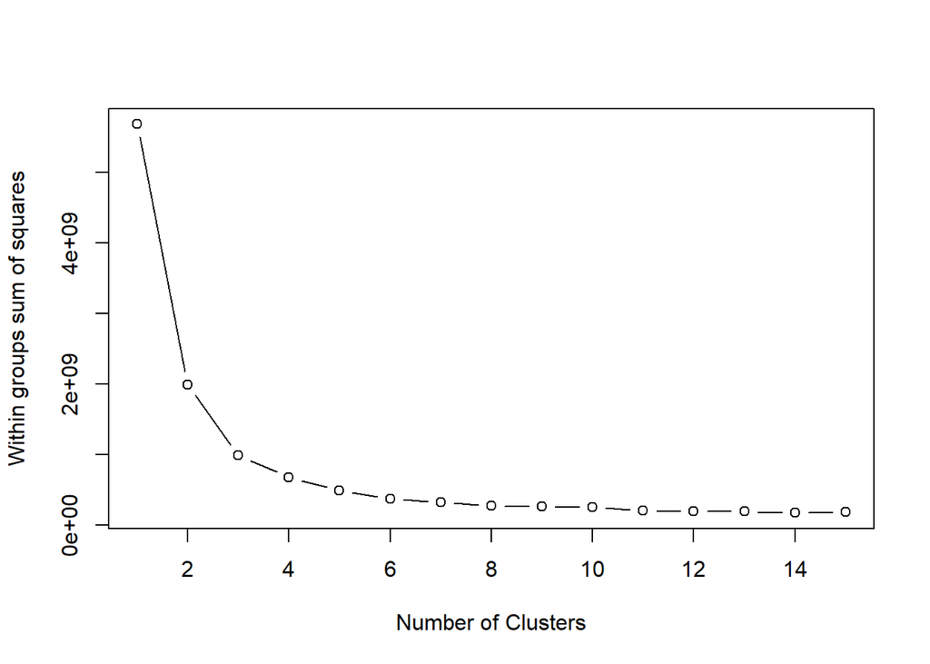

```r
# Determine number of clusters
wss <- (nrow(dta_num)-1)*sum(apply(dta_num,2,var))
for (i in 2:15) wss[i] <- sum(kmeans(dta_num, centers=i)$withinss)
plot(1:15, wss, type="b", xlab="Number of Clusters",ylab="Within groups sum of squares")
```

```r
# K-Means Cluster Analysis
fit <- kmeans(dta_num, 5) # 5 cluster solution
# get cluster means
aggregate(dta_num,by=list(fit$cluster),FUN=mean)
```

```
##   Group.1      HOF_n       SP     n_33       POS         G       AB
## 1       1 2.35294118 16.16471 16.16471 0.2764706 1914.8176 6720.882
## 2       2 0.09345794 11.27103 11.27103 0.5841121  690.9533 1673.864
## 3       3 3.85897436 19.53846 19.53846 0.2692308 2518.4359 9202.282
## 4       4 0.57446809 13.47518 13.47518 0.3581560 1435.1064 4765.344
## 5       5 0.15867159 12.01845 12.01845 0.4723247 1068.9852 3177.295
##           R         H        DB        TP        HR       RBI        SB
## 1  92.90882 183.50529 317.38235 49.323529 204.48235  90.14941 137.20000
## 2  19.14346  41.11729  70.84579  9.364486  32.04673  17.90187  21.97664
## 3 137.86923 261.01667 452.26923 74.294872 307.34615 129.20513 230.26923
## 4  62.87163 127.50000 217.93617 34.301418 115.35461  57.26986  94.80851
## 5  38.30369  81.45092 139.50923 19.878229  74.04428  36.96531  48.68635
##         CS        BB        SO       IBB      HBP       SH       SF
## 1 68.07647  685.2353  996.4824  67.41176 43.07647 46.18235 58.50588
## 2 13.41589  155.9813  277.5654  13.97664 11.61682 18.04673 12.93458
## 3 88.87179 1018.0641 1223.8974 117.92308 57.11538 49.82051 84.07692
## 4 48.22695  471.2872  696.2340  40.15957 32.96454 40.64894 38.99645
## 5 28.42804  304.6716  500.0996  29.13653 20.89299 30.37269 26.14022
##        GIDP      DBTP      BBSB      AVG      SLG      OBP       AW_P
## 1 153.38235 36.670588  82.24353 272.6176 425.9706 340.4353 2.50000000
## 2  39.64953  8.021028  17.79579 243.6776 353.1682 309.1869 0.02336449
## 3 206.26923 52.656410 124.83333 283.1667 448.1410 354.5513 6.20512821
## 4 106.56383 25.223759  56.60957 267.2234 400.0957 334.3156 0.64539007
## 5  74.68635 15.938745  35.33579 255.8708 381.7712 322.0627 0.22878229
##          AW_C        AWD       WAR
## 1 0.123529412 0.65294118 2.5326984
## 2 0.004672897 0.02803738 0.4078581
## 3 0.615384615 0.89743590 3.6234794
## 4 0.035460993 0.33333333 1.7530092
## 5 0.007380074 0.14391144 1.2125420
```

```r
# append cluster assignment
dta_num <- data.frame(dta_num, fit$cluster)
```

## Hierarchical Agglomerative

There are a wide range of hierarchical clustering approaches.

```r
# Ward Hierarchical Clustering
d <- dist(dta_num, method = "euclidean") # distance matrix
fit <- hclust(d, method="ward")
```

```
## The "ward" method has been renamed to "ward.D"; note new "ward.D2"
```

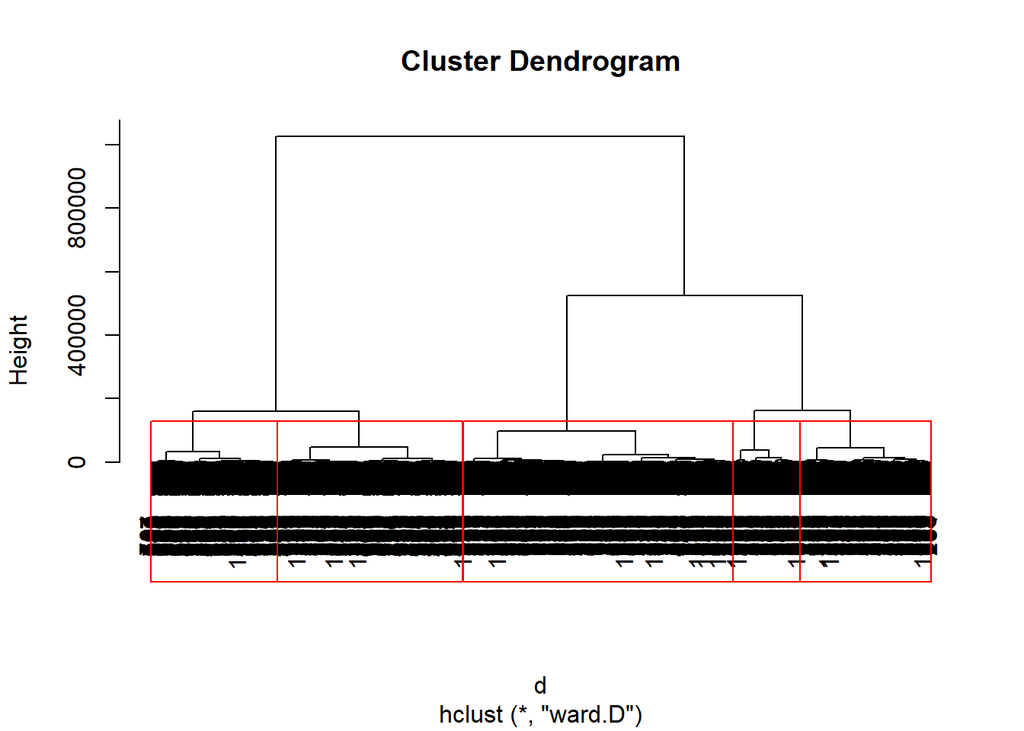

```r
plot(fit) # display dendogram
groups <- cutree(fit, k=5) # cut tree into 5 clusters
# draw dendogram with red borders around the 5 clusters
rect.hclust(fit, k=5, border="red")
```

The pvclust( ) function in the pvclust package provides p-values for hierarchical clustering based on multiscale bootstrap resampling. Clusters that are highly supported by the data will have large p values. Be aware that pvclust clusters columns, not rows; data must also be transposed first.

```r
# Ward Hierarchical Clustering with Bootstrapped p values
library(pvclust)
fit <- pvclust(dta_num, method.hclust="ward",
   method.dist="euclidean")
```

```
## The "ward" method has been renamed to "ward.D"; note new "ward.D2"
```

```
## Bootstrap (r = 0.5)... Done.
## Bootstrap (r = 0.6)... Done.
## Bootstrap (r = 0.7)... Done.
## Bootstrap (r = 0.8)... Done.
## Bootstrap (r = 0.9)... Done.
## Bootstrap (r = 1.0)... Done.
## Bootstrap (r = 1.1)... Done.
## Bootstrap (r = 1.2)... Done.
## Bootstrap (r = 1.3)... Done.
## Bootstrap (r = 1.4)... Done.
```

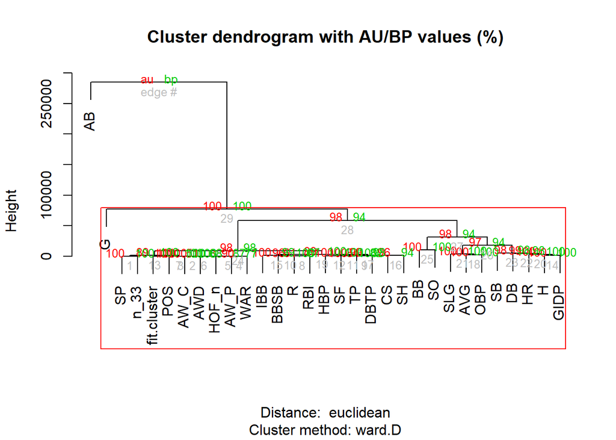

```r
plot(fit) # dendogram with p values
# add rectangles around groups highly supported by the data
pvrect(fit, alpha=.95)
```

Exploratory Analysis

Heatmap

Studying the correlation between each variable in the data set is valuable. If two variables are highly correlated, using them in the same predictive model will generate misleading results.

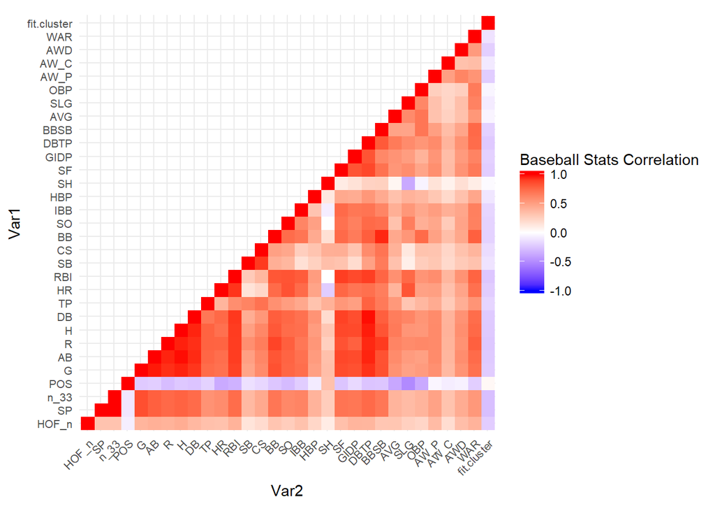

```r
library(ggplot2)
library(reshape2)##for melt
cor_mat <- cor(dta_num)
###half of matrix is redundant, use lower.tri function to set redundant values to NA
cor_mat[lower.tri(cor_mat)] <- NA
###must melt matrix for ggplot
melt_mat <- melt(cor_mat, na.rm = TRUE)
##plot
hmap <- ggplot(data = melt_mat, aes(Var2, Var1, fill = value)) +
  geom_raster(color = "white") +    ##faster than geom_tile()
  scale_fill_gradient2(low = "blue", high = "red", mid = "white", midpoint = 0, limit = c(-1,1), space = "Lab", name = "Baseball Stats Correlation") +      ## create gradient, darker approaching +- 1, provides legend
  theme_minimal()+      ##white background
  theme(axis.text.x = element_text(angle = 45, vjust = 1, size = 8, hjust = 1))+ ##rotate and shrink x axis labels
  theme(axis.text.y = element_text(size = 8))+
  coord_fixed()
plot(hmap)
```

Principal Components Analysis